# Project Assignment Machine Learning

MGA

26 jul 2018

## Datamanipulation

Since the quiz test dataset only consist of non-summary data, I chose to exclude the variables with more than 95% NAs.

```r
library(dplyr); library(ggplot2); library(caret)
#main <- read.csv("https://d396qusza40orc.cloudfront.net/predmachlearn/pml-training.csv",
#                     stringsAsFactors = F,
#                     na.strings = c("NA", ""))
#save(main, file = "C:/Kurser/Machine_Learning/main.Rdata")

load("C:/Kurser/Machine_Learning/main.Rdata")

#Identifying variables with more than 95% NAs, these are for practical purposes the summary variables that are all NAs in the samples for the final quiz.
manyNAs <- unname(which(sapply(main, function(x) sum(is.na(x))) >= 0.95 * nrow(main)))
main <- main[,-manyNAs]

#A litt´le more manipulation
main2 <- main %>%
  select(-X, -cvtd_timestamp) %>%
  mutate(user_name = as.factor(user_name),
         classe = as.factor(classe),
         new_window = as.factor(new_window),
         #raw_timestamp_part_2 = as.character(raw_timestamp_part_2),
         raw_timestamp_part_1 = substr(raw_timestamp_part_1, 7, 10),
         raw_timestamp_part_2 = ifelse(nchar(raw_timestamp_part_2) < 6,
                                       paste0(do.call(paste0, as.list(rep("0", 3))), raw_timestamp_part_2),
                                       raw_timestamp_part_2),
         raw_timestamp_part_2 = substr(raw_timestamp_part_2,
                                       nchar(raw_timestamp_part_2)-5,
                                       nchar(raw_timestamp_part_2)),
         time_stamp = paste(raw_timestamp_part_1, substr(raw_timestamp_part_2, 1, 5), sep = "."),
         time_stamp = as.numeric(time_stamp)) %>%
  select(-raw_timestamp_part_1, -raw_timestamp_part_2) %>%
  group_by(user_name, classe) %>%
  mutate(time_stamp = time_stamp - min(time_stamp)) %>%
  ungroup()

set.seed(26062018)
inTrain <- createDataPartition(main$classe, p = 0.80, list = F)

training <- main2[inTrain,]
```

## Plotting the variables

The below figure shows one variable (total_accel_belt) vs. time. All variables show the same type of pattern, a sinusoidal curve, in some of the classes and a more or less flat line i the others. It looks like there is a very time dependant strukture in the data, and also the relationship is non-linar.

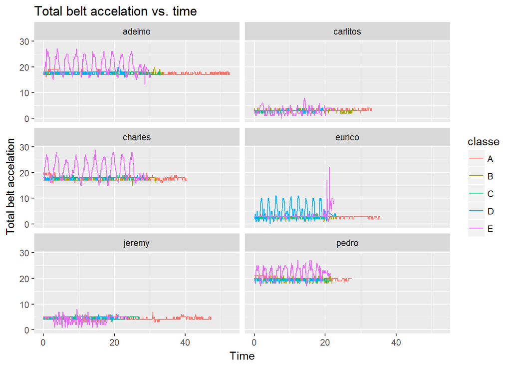

```r
ggplot(data = training, aes(y = total_accel_belt, x = time_stamp, color = classe)) +
  geom_line() +
  facet_wrap(~user_name, ncol = 2) +
  labs(title = "Total belt accelation vs. time",
       x = "Time",
       y = "Total belt accelation")
```

## Accuracy vs. interpretability

In order to decrease computation time and increase accuracy i chose to run a principle components analysis on my data prior to fitting my random forest algorithm. The variables are already quite difficult to interpret, so the accuracy/interpretability trade-off is not a big problem.

```r
pcaObj <- preProcess(x = training[-c(1:3, 56:57)], method = "pca")

trainingPca <- predict(pcaObj, training) %>%
  select(-(user_name:num_window), -time_stamp)
```

## Fitting the model

Because of time-consumption issues, i have run the model in an R-session, saved it and then load it here in the Rmarkdown. I have fitted a randomforest algorithm with 10 fold cross-validation.

```r
#fit1 <- train(classe ~ ., data = trainingPca, method = "rf", trControl = trainControl(method = "cv", number = 10))
#save(fit1, file = "C:/Kurser/Machine_Learning/fit1.Rdata")
load("C:/Kurser/Machine_Learning/fit1.Rdata")
fit1
```

```
## Random Forest
##
## 15699 samples
##    26 predictor
##     5 classes: 'A', 'B', 'C', 'D', 'E'
##
## No pre-processing
## Resampling: Cross-Validated (10 fold)
## Summary of sample sizes: 14131, 14130, 14129, 14129, 14130, 14128, ...
## Resampling results across tuning parameters:
##
##   mtry  Accuracy   Kappa
##    2    0.9770061  0.9709080
##   14    0.9752846  0.9687276
##   26    0.9703798  0.9625228
##
## Accuracy was used to select the optimal model using the largest value.
## The final value used for the model was mtry = 2.
```

I use the default metric (Accuracy) to select the optimal with model with regards to number of candidates at each split. The final model chose 2 randomly selected variables to be candidates at each split. The final accuracy on the training set is 97.7%.

## Out of sample error

Finally i construct my training set based on the principle components analysis performed earlier, predict the classes based on the testing data and calculate the accuracy and thereby get an estimate of the real predictive performance of my algorithm.

```r
testing <- main2[-inTrain,]

testingPca <- predict(pcaObj, testing) %>%
  select(-(user_name:num_window), -time_stamp)

conf_test <- confusionMatrix(testingPca$classe, predict(fit1, testingPca))
```

# Confusion matrix - test set

```r
knitr::kable(as.matrix(conf_test)/apply(conf_test$table, 2, sum))
```

|  | A | B | C | D | E |
| --- | --- | --- | --- | --- | --- |
| A | 0.9936994 | 0.0018002 | 0.0054005 | 0.0018002 | 0.0018002 |
| B | 0.0079893 | 0.9893475 | 0.0119840 | 0.0013316 | 0.0000000 |
| C | 0.0014006 | 0.0056022 | 0.9425770 | 0.0042017 | 0.0042017 |
| D | 0.0000000 | 0.0000000 | 0.0380349 | 0.9809826 | 0.0000000 |
| E | 0.0000000 | 0.0027933 | 0.0027933 | 0.0083799 | 0.9930168 |

```r
conf_test$overall[1]
```

```
##  Accuracy
## 0.9813918
```

The accuracy based on the test set is 98.1%, ie. higher than the accuracy from the training set which is a little bit strange, and dont have an explanation for this.